# Ejemplo función de utilidad

Febrero 2025

Un inversionista tiene $\$1000$ para invertir en dos tipo de acciones. Si invierte $\$m$ en la acción $A$ invertirá $\$(1000-m)$ en la acción $B$. Una inversión en la acción $A$ tiene una probabilidad de 0.7 de duplicar su valor y 0.3 de perder la inversión. Una inversión en la acción $B$ tiene una probabilidad de 0.6 de duplicar su valor y 0.4 de perder la inversión. Las probabilidades asociadas con la acción $A$ son independientes de las asociadas a la inversión $B$. Determinar el valor óptimo de $m$ si la función de utilidad del decisor para ganar o perder $x$ es $u(x)=log(x+3000)$.

## Función utilidad

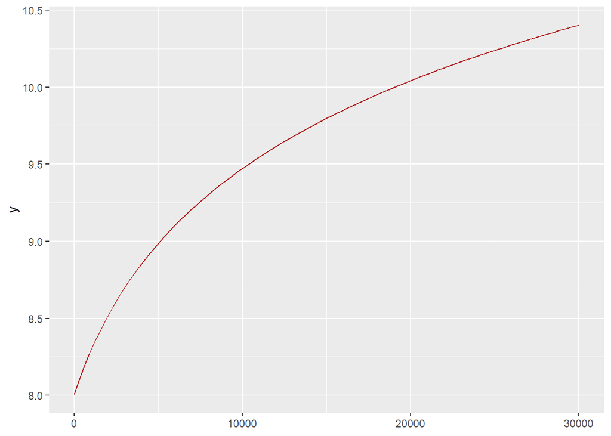

```r
u <- function(x){log(x+3000)}


ggplot()+
  geom_function(fun = u, xlim=c(0,30000), color= "firebrick")
```

```r
theme_bw()
```

[output not shown]

[output cut: 250 more lines]

[output not shown]

## Vector de valores monetarios X

```r
m <- 500

probabilidades <- c(0.42, 0.28, 0.18, 0.12)

x <- c(1000, 2*m-1000, 1000-2*m, -1000)
```

## Vector de probabilidades

```r
sum(probabilidades)
```

```
## [1] 1
```

## Valor monetario esperado

```r
Vm <- sum(x*probabilidades)
Vm
```

```
## [1] 300
```

## Utilidad esperada

```r
Ue <- sum(u(x)*probabilidades)
Ue
```

```
## [1] 8.078538
```

```r
FUe <- function(m){
  x <- c(1000, 2*m-1000, 1000-2*m, -1000)
  sum(u(x)*probabilidades)
}
```

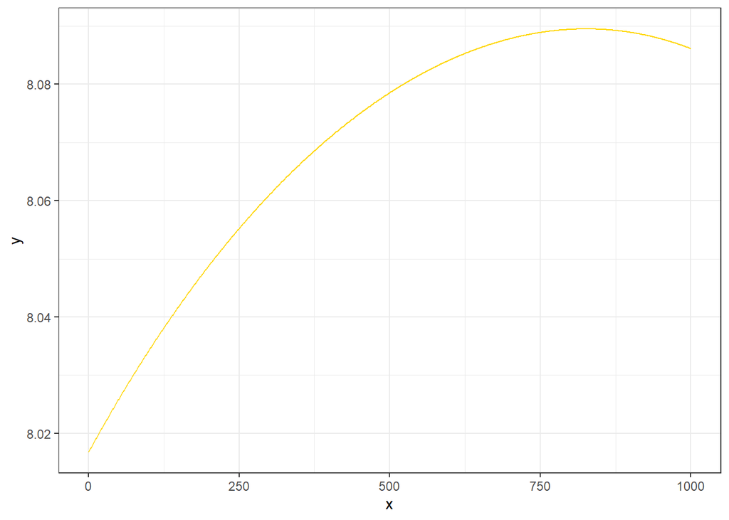

```r
x <- seq(0, 1000, by=1)
y <- unlist(lapply(x, FUe))

ggplot()+
  geom_line(aes(x,y), color="gold")+
  #geom_function(fun = FUe, xlim = c(0, 1000), color="dodgerblue4")+

theme_bw()
```

## Certidumbre equivalente

```r
xc <- exp(Ue)-3000
xc
```

```
## [1] 224.5163
```

## Prima de riesgo

Recordemos que la prima de riesgo $\pi$ es la parte máxima del valor monetario esperado que se está dispuesto a perder a fin de evitar el riesgo asociado a la inversión, y está dada por:

$$\begin{equation}
\pi=E(x|p)-x_c
\end{equation}$$

En este caso, primero sacamos la el valor monetario como función de m…

```r
x <- function(m){c(1000, 2*m-1000, 1000-2*m, -1000)}
```

```r
Ex <- function(m){sum(x(m)*probabilidades)}

Ex(m)
```

```
## [1] 300
```

Luego se encuenta el punto crítico

```r
m0 <- (0.56*4000-0.36*2000)/(0.36*2+0.56*2)
m0
```

```
## [1] 826.087
```

```r
prima <- Ex(m0)-xc
prima
```

```
## [1] 140.7011
```

## Aversión al riesgo local.

Recordemos que la función de riesgo total está definida por:

$$\begin{equation}
r(x)=-\frac{u''(x)}{u'(x)}
\end{equation}$$

En este caso es:

$$\begin{equation}
r(x)=\frac{1}{x+3000}
\end{equation}$$

Cuya gráfica es:

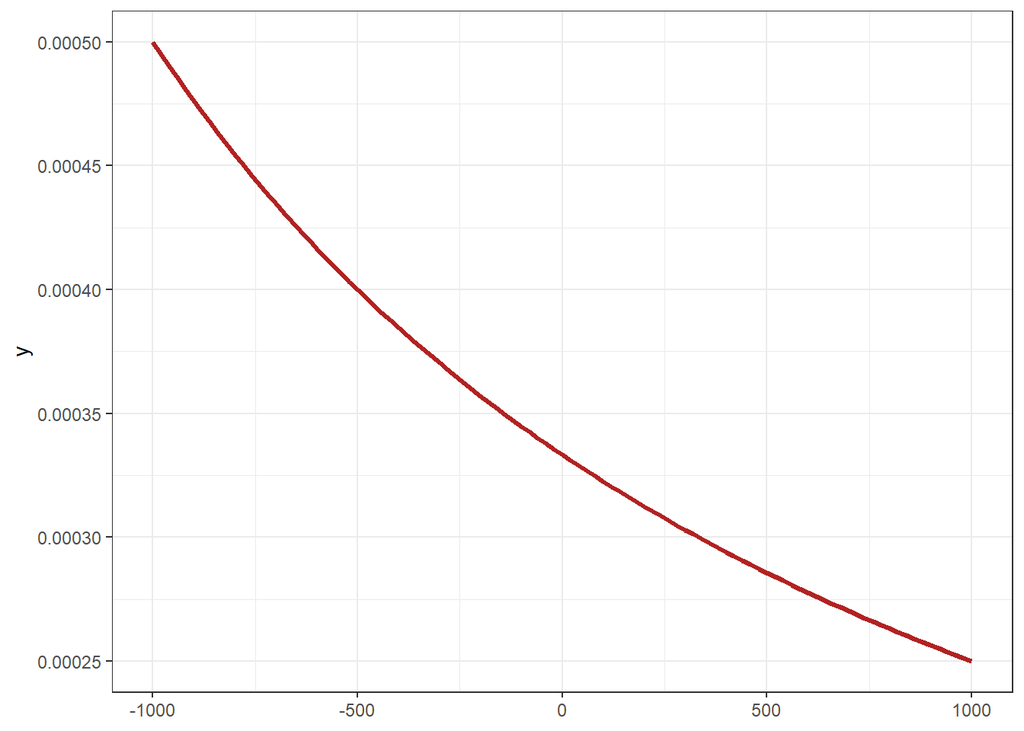

```r
rx <- function(x){1/(x+3000)}

ggplot()+
  geom_function(fun=rx, xlim=c(-1000, 1000), color="firebrick", linewidth=1.2)+
  theme_bw()
```

La cual es positiva para todo valor final monetario de las inversiones.